# Balanced Accuracy and the F1 Score

Machine Learning - Section $2.1.3$

Marc Omar Haddad

Created: 17 January, 2020

**Updated: 20 January, 2020**

As discussed previously, overall accuracy does not usually provide enough information to adequately assess an algorithm; hence the introduction of Sensitivity and Specificity. Indeed, a better (and more concise) metric than overall accuracy would be to find the **average** of Sensitivity and Specificity. This average is known as the **Balanced Accuracy**.

Because Sensitivity and Specificity are rates, it is more appropriate to compute their *harmonic average*, like so:

$$\frac{1}{\frac{1}{2}\left( \frac{1}{\mathrm{recall}}+\frac{1}{\mathrm{precision}} \right)}$$

Remember: **Recall** $= \frac{TP}{(TP+FN)}$, **Precision** $=\frac{TP}{(TP + FP)}$

The harmonic average above is also known as the **F1 Score**, and can be rewritten (for the sake of simplicity) like so:

$$2 \frac{\mathrm{precision} \cdot \mathrm{recall}}{\mathrm{precision} + \mathrm{recall}}$$

### Other Considerations

Different contexts call for the prioritization to minimize some errors over others (e.g. preferring higher Sensitivity at the cost of lower Specificity and vice versa).

Example: When it comes to plane safety, it is more important to maximize Sensitivity over Specificity. We assume **“Faulty”** to be the **“positive”** outcome:

- The cost of grounding a plane that is *predicted* to be faulty, but is *actually* not faulty (i.e. **False Positive**), is much less costly than *predicting* a plane to be not faulty, but which is *actually* faulty and results in a crash (i.e. **False Negative**).

Conversely, when it comes to capital murder cases, it is more important to maximize Specificity over Sensitivity. We assume **“Guilty”** to be the **“positive”** outcome:

- When determining guiltiness, the cost of *predicting* a person to be not guilty when in fact they are *actually* guilty (i.e. **False Negative**), is much less costly than *predicting* a person to be guilty and sentencing them to death despite *actually* being not guilty (i.e. **False Positive**).

### Weighted F1 Score and `F_meas`

Depending on the context, the F1 Score can be weighed accordingly. We use $\beta$ to denote how much more important Sensitivity is to Specificity. Our weighted F1 Score formula looks like this:

$$\frac{1}{\frac{\beta^2}{1+\beta^2} \frac{1}{\mathrm{recall}}+ \frac{1}{1+\beta^2}\frac{1}{\mathrm{precision}}}$$

In the `caret` package, the function `F_meas` returns a summary of the F1 Score, with $\beta$ defaulting to $1$.

Knowing this, we can now reconstruct our earlier predictive algorithm (see Sections $2.1.1$ and $2.1.2$) to **maximize our F1 Score**:

```r
cutoff = seq(61, 70)
F_1 = map_dbl(cutoff, function(x) {
  y_hat = ifelse(train_set$height > x, "Male", "Female") %>%
    factor(levels = levels(test_set$sex))
  F_meas(data = y_hat, reference = train_set$sex)
})
F_1
```

```
 [1] 0.211 0.323 0.439 0.566 0.605 0.614 0.582 0.557 0.508 0.468
```

Let us now compare our F1 Score values with their respective cutoffs:

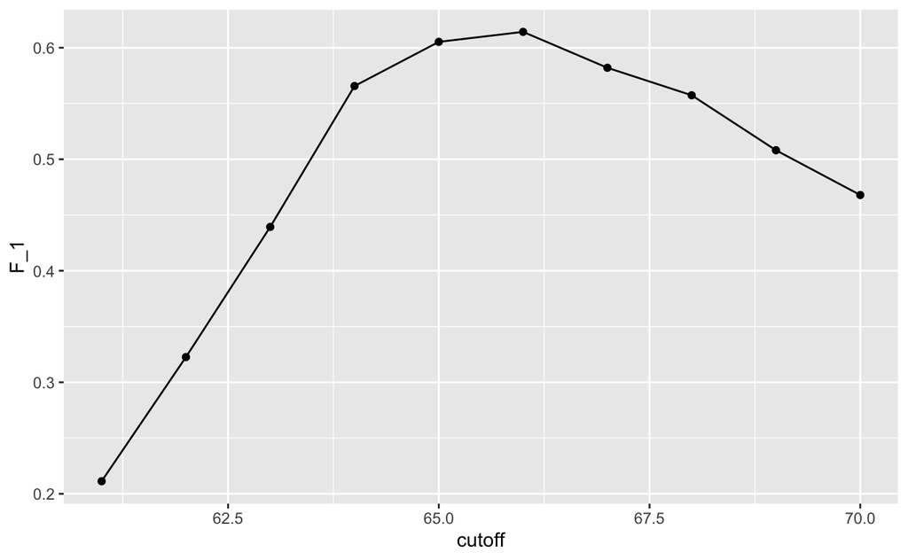

```r
max(F_1)
```

```
[1] 0.614
```

```r
best_cutoff = cutoff[which.max(F_1)]
best_cutoff
```

```
[1] 66
```

The maximum F1 Score is $0.614$, and is achieved by using a cutoff of $66$ inches. This is a more reasonable estimate than our previously obtained best cutoff of $64$ inches. Furthermore, if we analyze our new confusion matrix we can see that our Sensitivity and Specificity values are more balanced:

```r
y_hat = ifelse(test_set$height > best_cutoff, "Male", "Female") %>%
  factor(levels = levels(test_set$sex))
confusionMatrix(data = y_hat, reference = test_set$sex)
```

```
Confusion Matrix and Statistics

          Reference
Prediction Female Male
    Female     81   67
    Male       38  339

               Accuracy : 0.8
                 95% CI : (0.763, 0.833)
    No Information Rate : 0.773
    P-Value [Acc > NIR] : 0.07819

                  Kappa : 0.475

 Mcnemar's Test P-Value : 0.00629

            Sensitivity : 0.681
            Specificity : 0.835
         Pos Pred Value : 0.547
         Neg Pred Value : 0.899
             Prevalence : 0.227
         Detection Rate : 0.154
   Detection Prevalence : 0.282
      Balanced Accuracy : 0.758

       'Positive' Class : Female
```